# College_Major_Analysis

Zhengmao Zhu

September 3, 2018

## Instruction

Your assignment is to study how income varies across different categories of college majors. You will be using data from a study of recent college graduates. Make sure to use good practices that you have learned so far in this course and previous courses in the specialization.In particular, it is good practice to specify an analysis plan early in the process to avoid the “p-hacking” behavior of trying many analyses to find one that has desired results. If you want to learn more about “p-hacking”, you can visit https://projects.fivethirtyeight.com/p-hacking/.

## Load the data

```r
library("devtools")
devtools::install_github("jhudsl/collegeIncome")
library(collegeIncome)
data(college)

devtools::install_github("jhudsl/matahari")
library(matahari)
head(college)
```

```
  rank major_code                                     major major_category
1    1       2419                     Petroleum Engineering    Engineering
2    2       2416            Mining And Mineral Engineering    Engineering
3    3       2415                 Metallurgical Engineering    Engineering
4    4       2417 Naval Architecture And Marine Engineering    Engineering
5    5       2405                      Chemical Engineering    Engineering
6    6       2418                       Nuclear Engineering    Engineering
  total sample_size perc_women p25th median  p75th   perc_men
1  2339          36  0.9109326 25000  40000  50000 0.08906743
2   756           7  0.5154064 26000  37000  40000 0.48459355
3   856           3  0.5942076 26700  45000  60000 0.40579235
4  1258          16  0.6521298 26000  35000  45000 0.34787018
5 32260         289  0.4179248 31500  62000 109000 0.58207520
6  2573          17  0.4305368 23000  44700  50000 0.56946324
  perc_employed perc_employed_fulltime perc_employed_parttime
```

[output cut: 20 more lines]

## Clean the data

We testify whether missing values in the dataset, factor the variable major_category.

```r
sum(is.na(college$major_category))
```

```
[1] 0
```

```r
sum(is.na(college$median))
```

```
[1] 0
```

## Show the distribution and relationship of median of major_category

We make the boxplot and fit the original model.

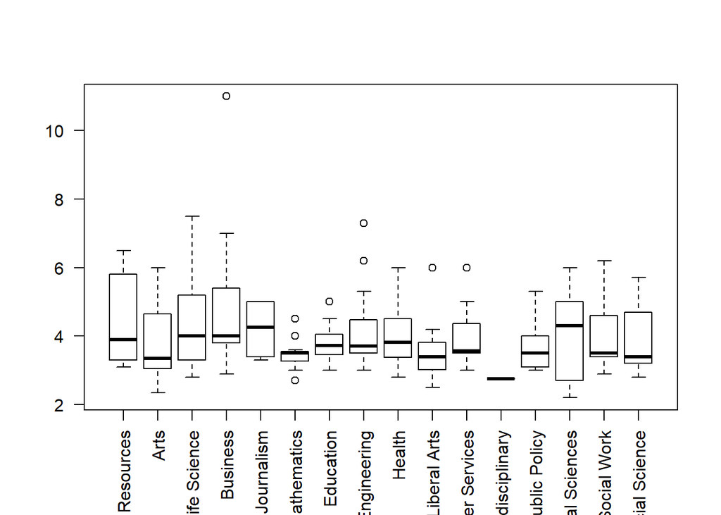

```r
college$major_category=as.factor(college$major_category)
model=lm(median~major_category, college)
boxplot(median/10000~major_category, college, las=2)
```

## Show the heatmap and the significance of major_category

We make the heatmap and find whether the significant association between college major category and income.

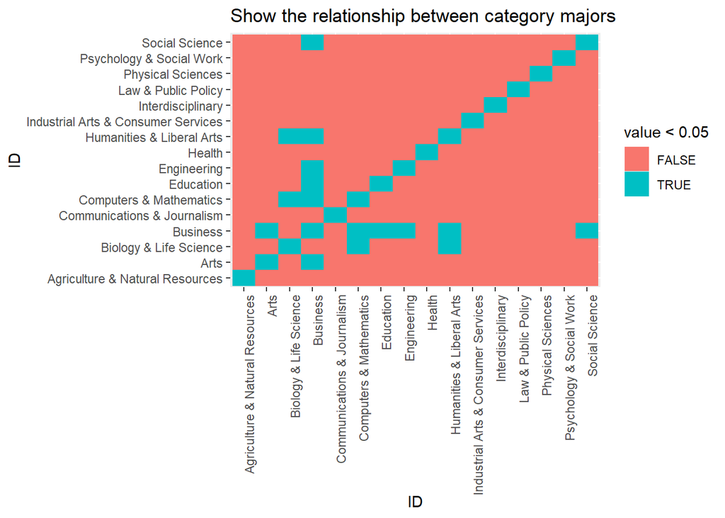

```r
library(reshape2)
library(ggplot2)

p_value_matrix=matrix(, nrow=16, ncol=16)
for (i in 1:16){
    major_category_reorder=relevel(college$major_category, sort(as.character(unique(college$major_category)))[i])
    fit_factor=lm(median~major_category_reorder, college)
    p_value_raw=summary(fit_factor)$coef[,4]
    p_value_sort=as.matrix(c(p_value_raw[1:i][-1],p_value_raw[1],p_value_raw[i:16][-1]))
    p_value_matrix[,i]=p_value_sort
}

p_value=data.frame(p_value_matrix)
names(p_value)=sort(as.character(unique(college$major_category)))
p_value$ID=sort(as.character(unique(college$major_category)))

p_value_final=melt(p_value)
g=ggplot(data=p_value_final, aes(x=variable, y=ID, fill=value<0.05))
g=g+geom_tile()
g=g+theme(axis.text.x=element_text(angle=90,hjust=1))+xlab("ID") + ylab("ID")
g=g+ggtitle("Show the relationship between category majors")
g
```

## Show the relationship between significant factor and others

```r
major_category_final=relevel(college$major_category, sort(as.character(unique(college$major_category)))[4])
fit_significant=lm(median~major_category_final, college)
summary(fit_significant)
```

```
Call:
lm(formula = median ~ major_category_final, data = college)

Residuals:
   Min     1Q Median     3Q    Max
-20154  -6800  -2893   4833  60846

Coefficients:
                                                        Estimate
(Intercept)                                                49154
major_category_finalAgriculture & Natural Resources        -5654
major_category_finalArts                                  -11104
major_category_finalBiology & Life Science                 -5290
major_category_finalCommunications & Journalism            -7154
major_category_finalComputers & Mathematics               -14436
major_category_finalEducation                             -11216
major_category_finalEngineering                            -8761
major_category_finalHealth                                 -8837
major_category_finalHumanities & Liberal Arts             -13987
major_category_finalIndustrial Arts & Consumer Services    -8725
major_category_finalInterdisciplinary                     -21654
major_category_finalLaw & Public Policy                   -11354
major_category_finalPhysical Sciences                      -8754
major_category_finalPsychology & Social Work               -9265
major_category_finalSocial Science                        -10087
                                                        Std. Error t value
(Intercept)                                                   3149  15.608
major_category_finalAgriculture & Natural Resources           4776  -1.184
major_category_finalArts                                      5102  -2.176
major_category_finalBiology & Life Science                    4374  -1.209
major_category_finalCommunications & Journalism               6493  -1.102
major_category_finalComputers & Mathematics                   4652  -3.103
major_category_finalEducation                                 4240  -2.645
major_category_finalEngineering                               3790  -2.311
major_category_finalHealth                                    4546  -1.944
major_category_finalHumanities & Liberal Arts                 4303  -3.251
major_category_finalIndustrial Arts & Consumer Services       5323  -1.639
major_category_finalInterdisciplinary                        11784  -1.838
major_category_finalLaw & Public Policy                       5976  -1.900
major_category_finalPhysical Sciences                         4776  -1.833
```

[output cut: 10 more lines]

```
major_category_finalEngineering                          0.02211 *
major_category_finalHealth                               0.05367 .
major_category_finalHumanities & Liberal Arts            0.00141 **
major_category_finalIndustrial Arts & Consumer Services  0.10321
major_category_finalInterdisciplinary                    0.06801 .
major_category_finalLaw & Public Policy                  0.05926 .
major_category_finalPhysical Sciences                    0.06873 .
major_category_finalPsychology & Social Work             0.06174 .
major_category_finalSocial Science                       0.04217 *
---
Signif. codes:  0 '***' 0.001 '**' 0.01 '*' 0.05 '.' 0.1 ' ' 1

Residual standard error: 11360 on 157 degrees of freedom
Multiple R-squared:  0.1054,    Adjusted R-squared:  0.01995
F-statistic: 1.233 on 15 and 157 DF,  p-value: 0.2522
```

From the heatmap and model results above, we know that Business is significant with Arts, Computers & Mathematics, Education, Engineering, Humanities & Liberal Arts and Social Science. However, the whole model is not significant. And between any other major categories, seldom of them have significant relationship. Therefore, except Business, any other major categories have similar incomes.